# Introduction to R using Yeast RNAseq data

# Manipulating data with **dplyr**

We can now explore this table and reshape it using `dplyr`. We will cover in this lesson:

`%>%`: pipes, they allow ‘concatenating’ functions

`select()`: subsets columns

`filter()`: subsets rows on conditions

`mutate()`: create new columns using information from other columns

`group_by()` and `summarize()`: create summary statistics on grouped data

`arrange()`: sort results

`count()`: counts discrete values

## Selecting columns and filtering rows

We have now a table with many columns- are all the columns useful to you? We can select columns using `select`, which requires as *arguments* the names of the colums that you want to keep:

```r
select(experiment_info, Sample, Yeast Strain, Nucleic Acid Conc., Sample, 260/280, Total RNA)
```

What happened? There is a space that R cannot deal well with- we can help R by adding back commas around the `name of the column`. These tell R `this is a word`:

```r
select(experiment_info, Sample, `Yeast Strain`, `Nucleic Acid Conc.`, `260/280`, `Total RNA`)
```

so let’s store that in `experiment_info` together with A260 and A280:

```r
experiment_info <- select(experiment_info, Sample, `Yeast Strain`, `Nucleic Acid Conc.`, A260, A280, `260/280`, `Total RNA`)
```

**NOTE**: When choosing names from cloumns, make sure that you choose something simple, all lowercase, all uppercase, or CamelCase. Having spaces in column names is not a good idea!

We select all columns *except for* by using ‘-’ before the name of the columns we do not want to include, for example all columns except for A260 and A280:

```r
select(experiment_info, -A260, -A280)
```

We can also `filter` rows based on conditions in a column:

```r
filter(experiment_info, `Nucleic Acid Conc.` > 1500)
```

### Exercise 1

> Select the columns Sample, Yeast Strain, A260 and A280 and assign that to a new object called experiment_data.

**Solution #1**

```r
experiment_data <-  select(experiment_info, Sample, `Yeast Strain`, A260, A280)
```

### Exercise 2

> Filter rows for only WT strains that had more than 1500 ng/uL concentration and make a new tibble called wild_type.

**Solution #2**

```r
  wild_type <- filter(experiment_info, `Yeast Strain` %in% 'WT' & `Nucleic Acid Conc.` > 1500)
```

## Pipes

What if we want to `select` and `filter` at the same time? We use %>% (pipes) for that. Pipes are available via the `magrittr` package, installed automatically with `dplyr`. If you use RStudio, you can type the pipe with `Ctrl + Shift + M` if you have a PC or `Cmd + Shift + M` if you have a Mac.

We can combine the characteristics from Exercise 1 and 2 using pipes `%>%` :

```r
experiment_info_wt <- experiment_info %>%
  filter(`Yeast Strain` %in% 'WT' & `Nucleic Acid Conc.` > 1500) %>%
  select(Sample, `Yeast Strain`, A260, A280)
```

### Exercise 3

> Using pipes, subset experiment_info to include all the samples that had a concentration less than 1500 and where total RNA was more or equal than 40 ug and retain only the columns that tell you the sample, yeast strain, nucleic acid concentration and total RNA. Assign that to a new table called samples_sequenced.

**Solution #3**

```r
samples_sequenced <- experiment_info %>%
  filter(`Nucleic Acid Conc.` < 1500 & `Total RNA` >= 40) %>%
  select(Sample, `Yeast Strain`,`Nucleic Acid Conc.`,`Total RNA`)
```

## Mutate

What if I want to create new columns? I use the function `mutate` for this. Let’s convert our units into micrograms/microliter:

```r
experiment_info %>%
  mutate(concentration_ug_uL = `Nucleic Acid Conc.` / 1000)
```

Or create more than one column! And pipe that into head so that we have a peep:

```r
experiment_info %>%
  mutate(concentration_ug_uL = `Nucleic Acid Conc.` / 1000,
          half_concentration = concentration_ug_uL / 1000) %>%
  head()
```

### Exercise 4

> Create a new table called library_start that includes the columns sample, yeast strain and two new columns called RNA_100 with the calculation of microliters to have 100ng of RNA and another column called water that says how many microliters of water we need to add to that to reach 50uL.

**Solution #4**

```r
library_start <- experiment_info %>%
  mutate(RNA_100 = 100/ `Nucleic Acid Conc.`,
          water = 50 - RNA_100) %>%
  select(Sample, `Yeast Strain`, RNA_100, water)
```

### Exercise 5

> Pretty difficult to pipette! Can redo the table considering a 1:10 dilution of your samples? Include the columns of A260 and A280 values in addition to sample, yeast strain, RNA_100 and water.

**Solution #5**

```r
library_start_diluted <-  experiment_info %>%
  mutate(diluted_RNA = 10/ `Nucleic Acid Conc.`,
          water = 50 - diluted_RNA) %>%
  select(Sample, `Yeast Strain`, `A260`, `A280`, diluted_RNA, water)
```

### Exercise 6

> Based on the tibble library_start_diluted, create a new tibble called `seq_samples` that includes only samples with a A260/A280 ratio of 2.2 or more and that only contains the columns for sample, yeast strain, A260280 ratio, diluted RNA and water.

**Solution #6**

```r
seq_samples <- library_start_diluted %>%
  mutate(A260_A280 = `A260`/`A280`) %>%
  filter(A260_A280 >= 2.2) %>%
  select(Sample, `Yeast Strain`, A260_A280, diluted_RNA, water)
```

## Split-apply-combine

The approach of split-apply-combine allows you to *split* the data into groups, *apply* a function/analysis and then *combine* the results. We can do this usign `group-by()` and `summarize()`.

`group_by()` takes as *argument* the column names that contain categorical variables that we want to calculate summary stats for. For example, to determine the average RNA concetration per strain:

```r
experiment_info %>%
  group_by(`Yeast Strain`) %>%
  summarize(mean_concentration = mean(`Nucleic Acid Conc.`))
```

or summarize using more than one column:

```r
experiment_info %>%
  group_by(`Yeast Strain`) %>%
  summarize(mean_concentration = mean(`Nucleic Acid Conc.`),
            mean_total_RNA = mean(`Total RNA`))
```

NOTE: Our table does not have missing values. However, we have in-built functions in R that can deal with this. We can filter values that are NOT na:

```r
experiment_info %>%
  group_by(`Yeast Strain`) %>%
  summarize(mean_concentration = mean(`Nucleic Acid Conc.`, na.rm = TRUE), # na.rm removes NA values while calculating the mean
            mean_total_RNA = mean(`Total RNA`))

experiment_info %>%
  filter(!is.na(`Nucleic Acid Conc.`)) %>%   # we filter out the values that are not NAs before we do any calculations
  group_by(`Yeast Strain`) %>%
  summarize(mean_concentration = mean(`Nucleic Acid Conc.`),
            mean_total_RNA = mean(`Total RNA`))
```

We can now arrange the data in ascending order (default of `arrange()`) or descending using `desc()`:

```r
experiment_info %>%
  filter(!is.na(`Nucleic Acid Conc.`)) %>%  # we filter out the values that are not NAs before we do any calculations
  group_by(`Yeast Strain`) %>%
  summarize(mean_concentration = mean(`Nucleic Acid Conc.`),
            mean_total_RNA = mean(`Total RNA`)) %>%
  arrange(mean_concentration) # arranges our new table in ascending mean concentrations

experiment_info %>%
  filter(!is.na(`Nucleic Acid Conc.`)) %>%  # we filter out the values that are not NAs before we do any calculations
  group_by(`Yeast Strain`) %>%
  summarize(mean_concentration = mean(`Nucleic Acid Conc.`),
            mean_total_RNA = mean(`Total RNA`)) %>%
  arrange(desc(mean_concentration) # arranges our new table in descending mean concentrations
```

Another useful function is `count()` to count categorical values:

```r
experiment_info %>%
  count(`Yeast Strain`)
```

# Combining Datasets using `join`

In many ocassions we will have more than one table that we need to extract information from. We can easily do this in R using the family of `join` functions.

We are going to first download extra information about the samples that we are are investigating and assing them to an object called *ena_info*:

```r
ena_info <- read_tsv(file = 'https://osf.io/6s4cv/download')
sample_mapping <- read_tsv(file = 'https://osf.io/uva3r/download')
```

### Exercise 7

> Explore your new dataset ena_info and sample_mapping. What commands can you use?

**Solution #7**

```r
head(ena_info)
tail(ena_info)
str(ena_info)
class(ena_info)
dim(ena_info)
summary(ena_info)

# and the same with sample_mapping!
```

The `join` functions allow you to merge tables considering columns/rows characteristics, so that you can do cool stuff such as (taken from R cheatsheets!):

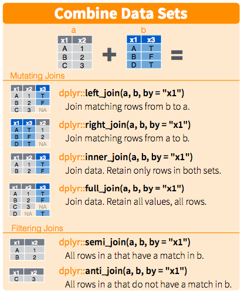

We have run accession numbers in both our tibbles `sample_mapping` and `ena_info`. We want now to merge both datasets to link the characteristics present in both tables in one big table that contains everything. We need a column that has the same name in both tables. **Challenge**: which function would you use if the column names where not the same?

```r
sample_mapping <- rename(sample_mapping, run_accession = RunAccession) # would rename a column called Sample into sample_number to match with the column sample_number in ena_info
yeast_metadata_right <- right_join(ena_info, sample_mapping, by = "run_accession") # this will join both tables matching rows from experiment_info in ena_info
```

That is a big table!

### Exercise 8

> How would you merge both tables so that only the rows that are common between both tables are preserved?

**Solution #8**

```r
yeast_metadata_inner <- inner_join(ena_info, sample_mapping, by = "run_accession")
yeast_metadata_left <- left_join(ena_info, sample_mapping, by = "run_accession")
```

We will work from now onwards with the tibble `yeast_metadata_inner`.

### Exercise 9

> We do not want all the columns; we want to create a new tibble called `yeast_metadata` that contains only run accession, experiment alias, read count, fastq bytes and md5, lane, yeast strain and biological replicate. Rename the column names so that all of the column names are lower_case (lowercase followed by underscore). And include only data from lane number 1. Use pipes!

**Solution #9**

```r
yeast_metadata <-  yeast_metadata_inner %>%
  rename(yeast_strain = Sample, lane = Lane, biol_rep = BiolRep) %>%
  filter(lane == 1) %>%
  select(run_accession, experiment_alias, read_count, fastq_bytes, fastq_md5, lane, yeast_strain, biol_rep)

head(yeast_metadata)
```

```
## # A tibble: 6 x 8
##   run_accession experiment_alias read_count fastq_bytes fastq_md5  lane
##   <chr>         <chr>                 <dbl>       <dbl> <chr>     <dbl>
## 1 ERR458493     ena-EXPERIMENT-…    1093957    59532325 2b8c708c…     1
## 2 ERR458500     ena-EXPERIMENT-…    1885330   102201086 107aad97…     1
## 3 ERR458507     ena-EXPERIMENT-…    1594160    86382961 93bca10a…     1
## 4 ERR458514     ena-EXPERIMENT-…    1594695    86462515 48fa134b…     1
## 5 ERR458521     ena-EXPERIMENT-…    1977253   106992945 98a9d336…     1
## 6 ERR458528     ena-EXPERIMENT-…    1371825    74704461 e4bf39d6…     1
## # … with 2 more variables: yeast_strain <chr>, biol_rep <dbl>
```

We also want to create a table called `salmon_samples` that will include our 6 samples that we used in `salmon`, namely samples ‘ERR458493’,‘ERR458494’,‘ERR458495’,‘ERR458500’,‘ERR458501’and ’ERR458502’.

```r
samples <- c('ERR458493','ERR458494','ERR458495','ERR458500','ERR458501','ERR458502') # we create a vector that includes the samples that we want to subset
salmon_samples <- yeast_metadata_inner %>%
  filter(run_accession %in% test$samples) # we filter rows based on these sample names
```

# Making plots with ggplot2

We have learnt how to manipulate datasets and combine them. We do this to have a table that is useful for our purposes, which in many occassions is to produce nice plots :). We are going to see the basics of how plotting happens in R using the package `ggplot2` which is part of `tidyverse`.

The basic *syntax* of ggplot2 is:

```r
ggplot(data = <DATA>, mapping = aes(<MAPPINGS>)) +
  <GEOM_FUNCTION>()
```

We are going to make some simple plots to explore our yeast_metadata tibble. There is A LOT more that can be done, lots of options, etc! This is only a taste for what you can do in `ggplot2`.

We build plots in ‘layers’:

```r
ggplot(data = yeast_metadata)
```

binds the plot to a specific data frame using the `data` argument

```r
ggplot(data = yeast_metadata, mapping = aes, mapping = aes(x = read_count, y = fastq_bytes))
```

defines the mapping using `aes` (aesthetics of the plot) by selecting the variables to be plotted and how they will be plotted (e.g. x/y, size, shape, color…)

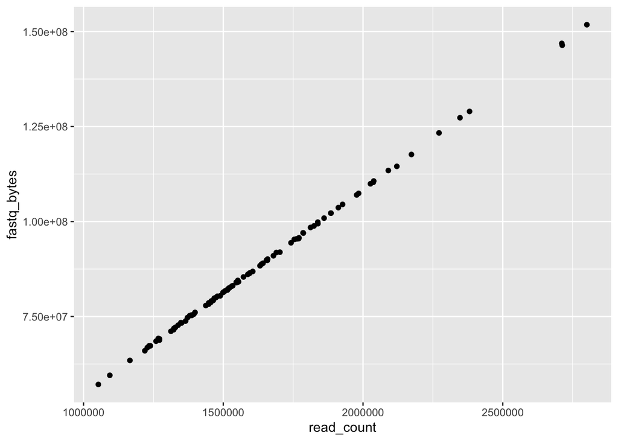

```r
ggplot(data = yeast_metadata, mapping = aes(x = read_count, y = fastq_bytes)) +
  geom_point()
```

which sets what type of plot we want to have (boxplot, lines, bars):

`geom_point()` for scatter plots, dot plots, etc.;

`geom_boxplot()` for boxplots;

`geom_line()` for trend lines, time series, etc.

We can modify plots to extract more information. We can add transparency:

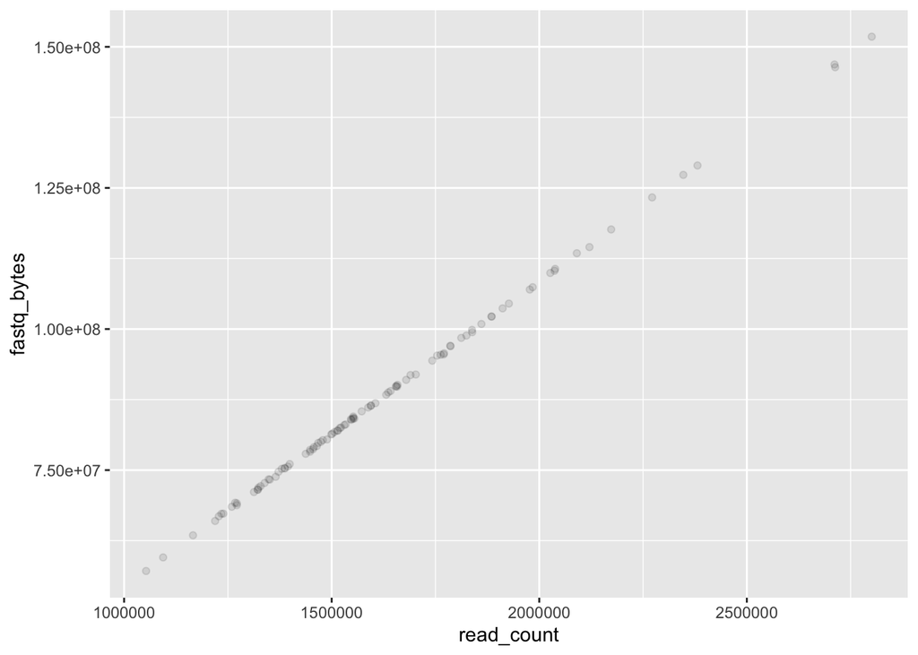

```r
ggplot(data = yeast_metadata, mapping = aes(x = read_count, y = fastq_bytes)) +
  geom_point(alpha = 0.1)
```

or change the color of the points:

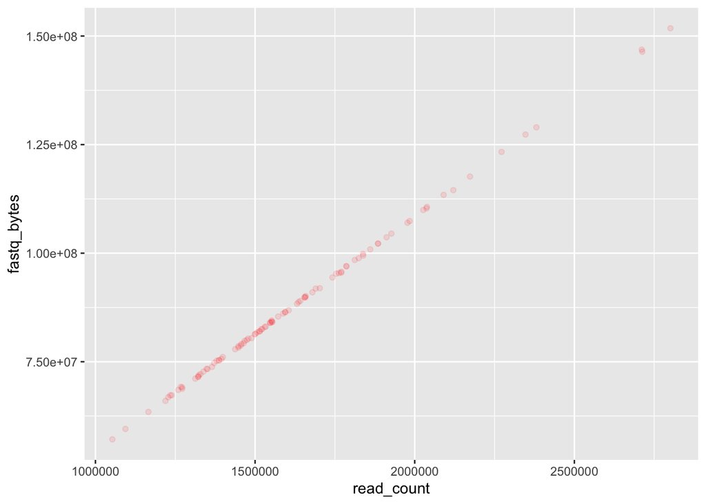

```r
ggplot(data = yeast_metadata, mapping = aes(x = read_count, y = fastq_bytes)) +
  geom_point(alpha = 0.1, color = "red")
```

Or color each strain differently:

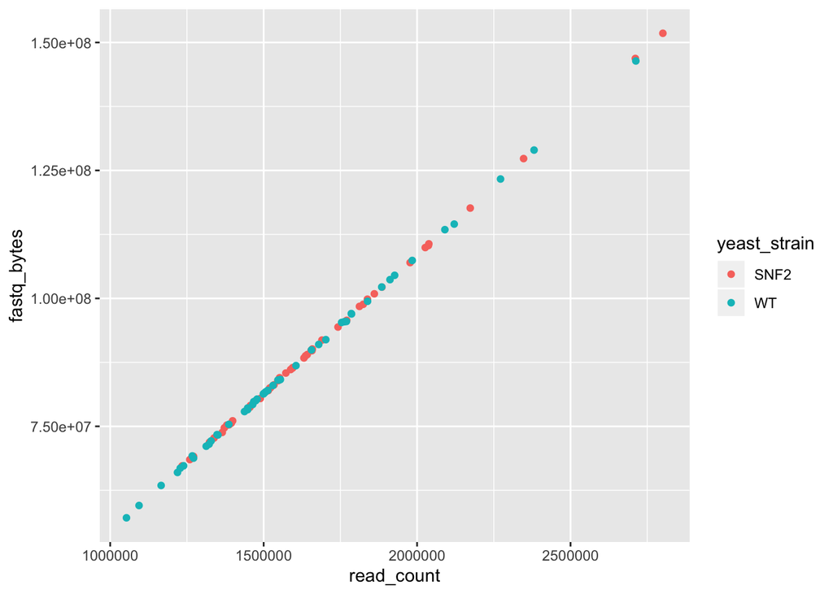

```r
ggplot(data = yeast_metadata, mapping = aes(x = read_count, y = fastq_bytes)) +
  geom_point(alpha = 1, aes(color = yeast_strain))
```

We can also specify the color inside the mapping:

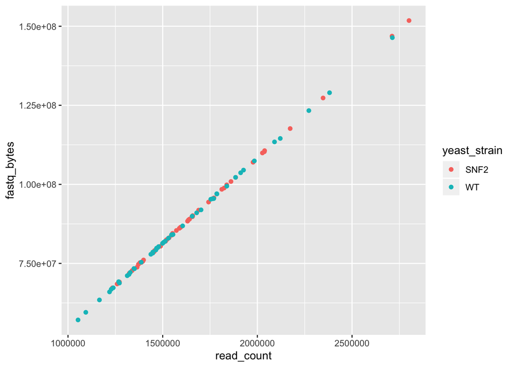

```r
ggplot(data = yeast_metadata, mapping = aes(x = read_count, y = fastq_bytes, color = yeast_strain)) +
  geom_point(alpha = 1)
```

or try different geom layers:

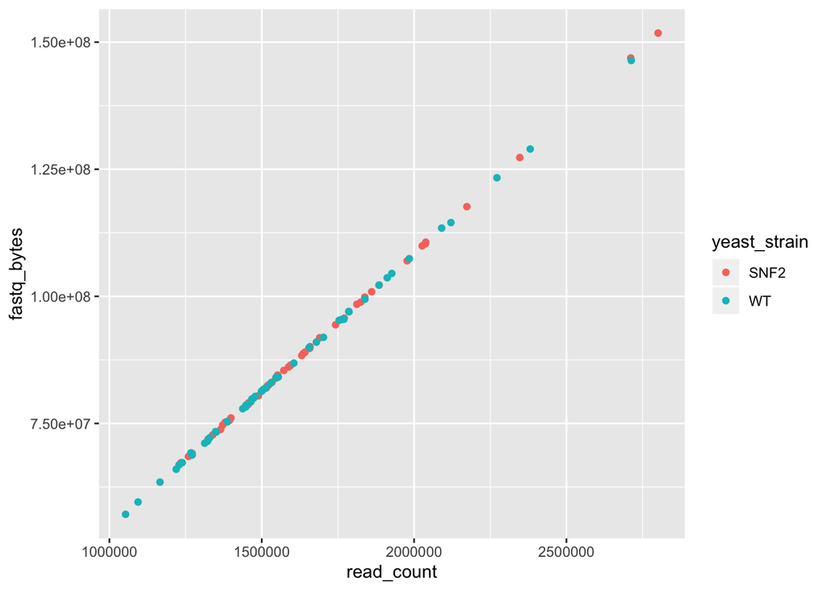

```r
ggplot(data = yeast_metadata, mapping = aes(x = read_count, y = fastq_bytes, color = yeast_strain)) +
  geom_jitter(alpha = 1)
```

We can use boxplots to see the distribution of reads within strains:

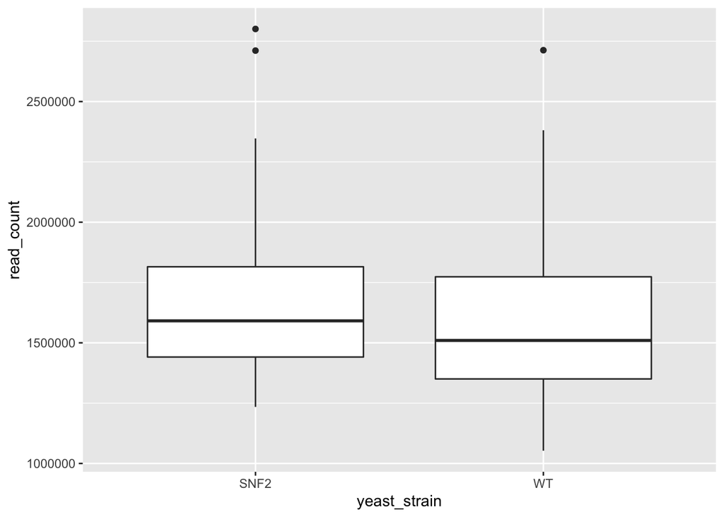

```r
ggplot(data = yeast_metadata, mapping = aes(x = yeast_strain, y = read_count)) +
  geom_boxplot()
```

This is useful, but if we add dots to the boxplots we will have a better idea of the number of measurements and their distribution:

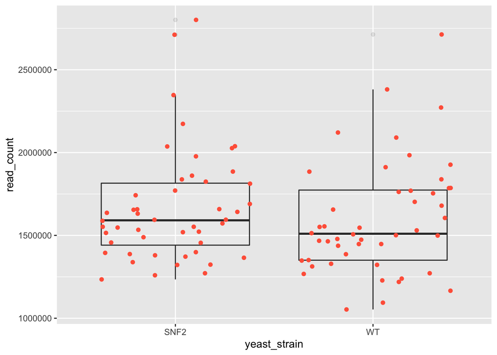

```r
ggplot(data = yeast_metadata, mapping = aes(x = yeast_strain, y = read_count)) +
  geom_boxplot(alpha = 0.1) +
  geom_jitter(alpha = 1, color = "tomato")
```

### Exercise 10

> Replace the boxplot with a violin plot.

**Solution #10**

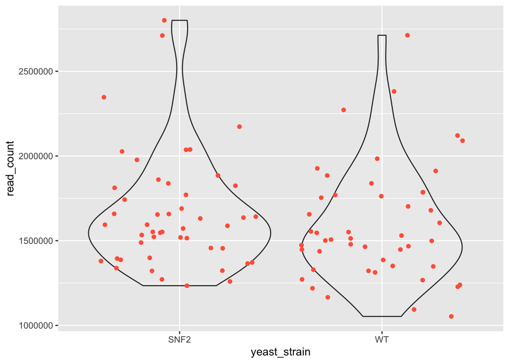

```r
ggplot(data = yeast_metadata, mapping = aes(x = yeast_strain, y = read_count)) +
  geom_violin(alpha = 0.1) +
  geom_jitter(alpha = 1, color = "tomato")
```

### Exercise 11

> Represent the read_count on log10 scale. Check out `scale_y_log10()`.

**Solution #11**

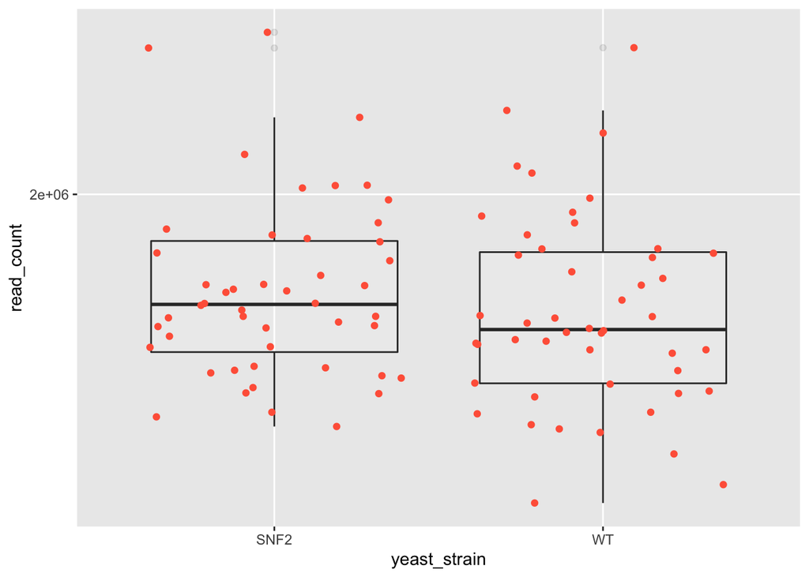

```r
ggplot(data = yeast_metadata, mapping = aes(x = yeast_strain, y = read_count)) +
  scale_y_log10() +
  geom_boxplot(alpha = 0.1) +
  geom_jitter(alpha = 1, color = "tomato")
```

### Exercise 12

> Try to make a histogram plot for the read counts, coloring each yeast strain.

**Solution #12**

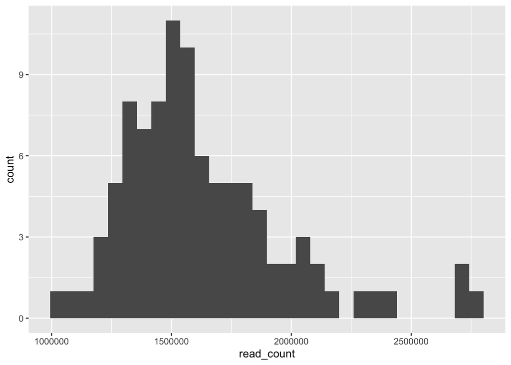

```r
# Basic histogram
ggplot(data = yeast_metadata, aes(x=read_count)) +
  geom_histogram()
```

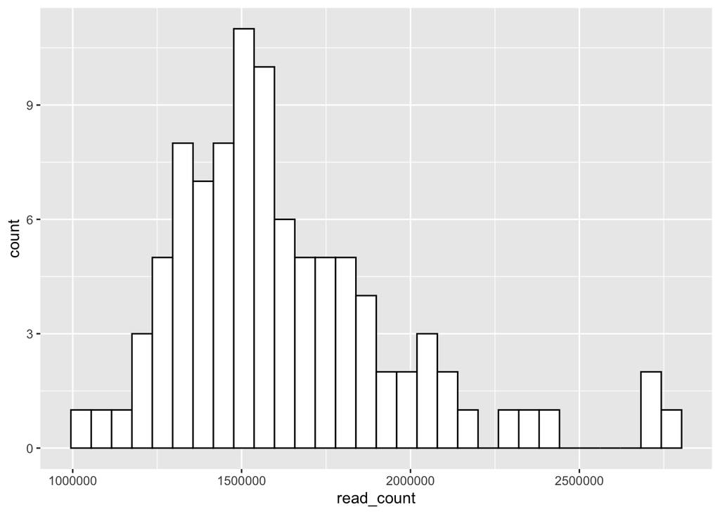

```r
# Change colors
p<-ggplot(data = yeast_metadata, aes(x=read_count)) +
  geom_histogram(color="black", fill="white")
p
```

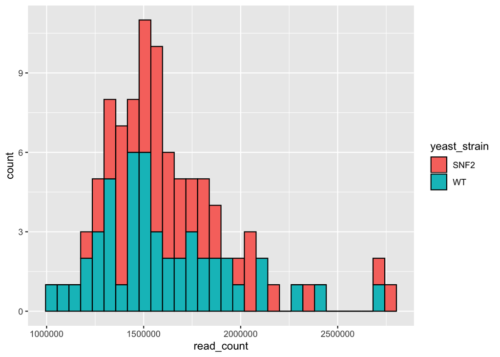

```r
# Change colors based on yeast strain
ggplot(data = yeast_metadata, aes(x=read_count, fill = yeast_strain)) +
  geom_histogram(color="black")
```

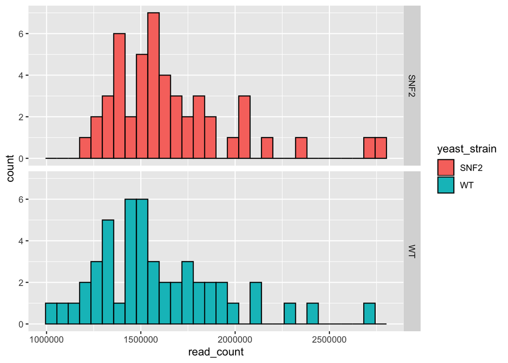

```r
# Facet based on yeast strain
ggplot(data = yeast_metadata, aes(x=read_count, fill = yeast_strain)) +
  geom_histogram(color="black") +
  facet_grid(yeast_strain~.)
```

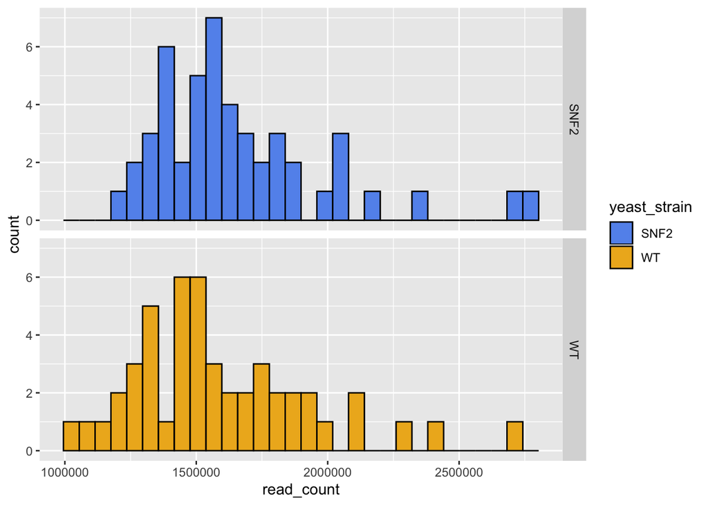

```r
# Change to custom colors that are color blind friend
ggplot(data = yeast_metadata, aes(x=read_count, fill = yeast_strain)) +
  geom_histogram(color="black") +
  facet_grid(yeast_strain~.) +
  # Add blue and yellow colors that are more colorblind friendly for plotting
  scale_fill_manual(values = c("cornflowerblue", "goldenrod2"))
```

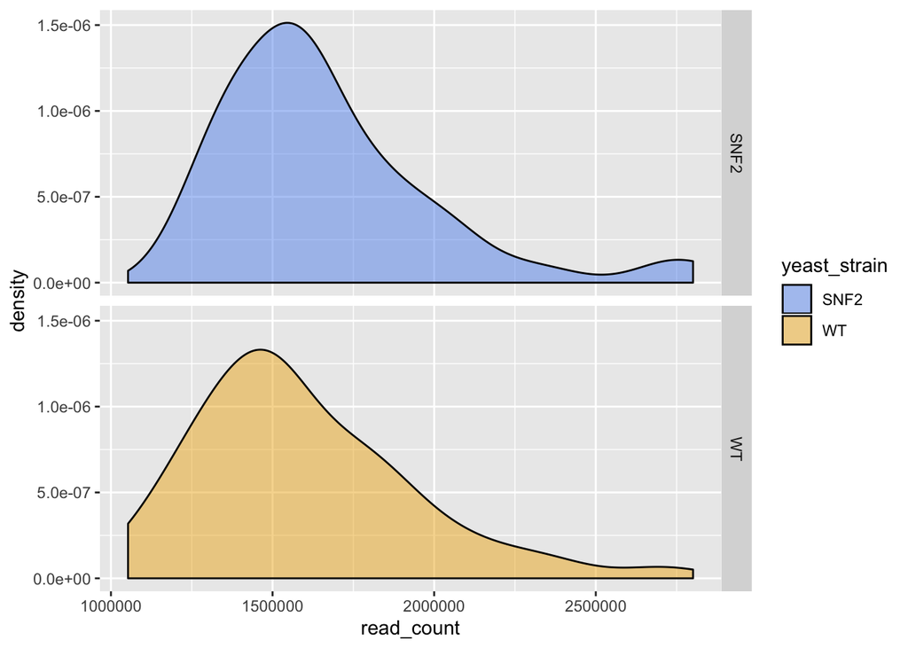

```r
# Density based on yeast strain
ggplot(data = yeast_metadata, aes(x=read_count, fill = yeast_strain)) +
  facet_grid(yeast_strain~.) +
  geom_density(alpha = 0.5) +
  scale_fill_manual(values = c("cornflowerblue", "goldenrod2"))
```

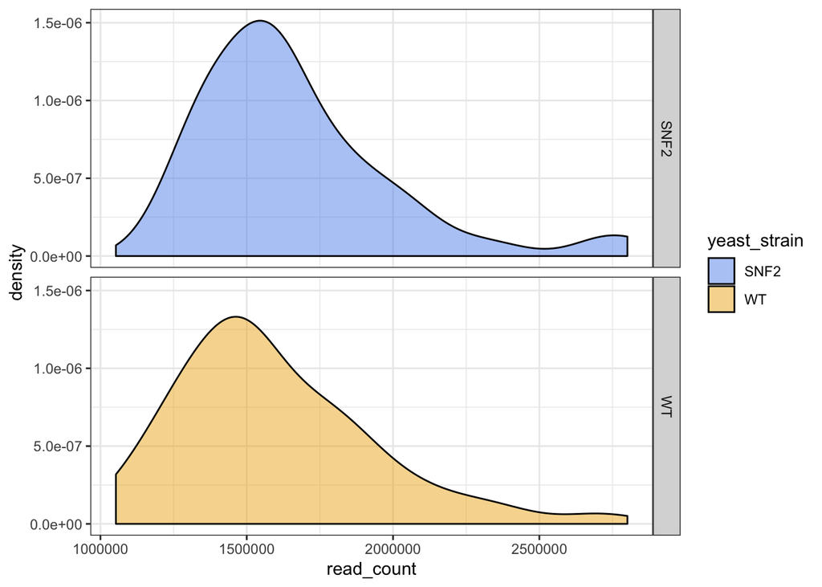

```r
# A white background might be preferable for the yellow color
ggplot(data = yeast_metadata, aes(x=read_count, fill = yeast_strain)) +
  facet_grid(yeast_strain~.) +
  geom_density(alpha = 0.5) +
  scale_fill_manual(values = c("cornflowerblue", "goldenrod2")) +
  theme_bw()
```

### Exercise 13

> What if we want to add the mean read counts in a vertical line?

**Solution #13**

```r
# To do so, we need to calculate the mean_read_count in a new data frame
mean_yeast_data <- yeast_metadata %>%
  group_by(yeast_strain) %>%
  summarise(mean_read_count = mean(read_count))
mean_yeast_data
```

```
## # A tibble: 2 x 2
##   yeast_strain mean_read_count
##   <chr>                  <dbl>
## 1 SNF2                1665717.
## 2 WT                  1596525.
```

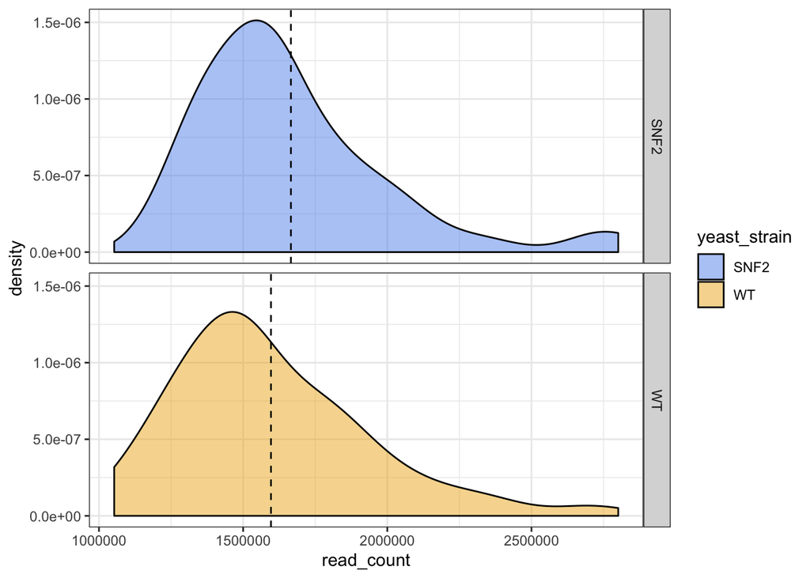

```r
# Add the mean read_count with vline
ggplot(data = yeast_metadata, aes(x=read_count, fill = yeast_strain)) +
  geom_density(alpha = 0.5) +
  facet_grid(yeast_strain~.) +
  geom_vline(data = mean_yeast_data, mapping = aes(xintercept = mean_read_count),
             linetype="dashed", size=0.5) +
  theme_bw() +
  scale_fill_manual(values = c("cornflowerblue", "goldenrod2"))
```

# More material

There are many amazing resources and cheat sheets to continue learning R, including:

- [R Cookbook](http://www.cookbook-r.com/)
- [Data Wrangling Cheat Sheet](https://www.rstudio.com/wp-content/uploads/2015/02/data-wrangling-cheatsheet.pdf)
- [ggplot](https://www.rstudio.com/wp-content/uploads/2015/03/ggplot2-cheatsheet.pdf)
- [R Colors](http://www.stat.columbia.edu/~tzheng/files/Rcolor.pdf)
- [Software Carpentry R Lesson](http://swcarpentry.github.io/r-novice-gapminder/)